# **Consulting for a Company Planning to Launch a Health & Wellness App**

**1. Introduction**

Since we are in 2026, all of us know that massive use of smartphones/tablets/laptops has been identified as one of the major issues that is impacting individuals' mental health and productivity. Also they are having lack of sleep and it affects their daily routines. Our collaborating firm is a healthy lifestyle application that is intended to improve individuals' lifestyle and influence them to use smartphones in a healthy way. However, currently, the application is unable to identify and evaluate the level of addiction of its users. This is where we are.

The major aim of this project is to create a predictive model that can forecast individuals' levels of smartphone addiction based on their characteristics. By being able to identify and forecast individuals' levels of smartphone addiction, the firm can improve its application's recommendation and value proposition in the competitive market.

The data we collect from that firm will help us to improve their business. The main goal is here to detect and automate the customers behaviors with that firm can adjust their recommendation settings for people accurately.

1.1 **The Data We Got and How We Use**

The dataset they gave represents behavioral and usage patterns of 7,500 smartphone users. It includes different aspects of their behavior. Each row in the dataset represents how users behave and interact with their smartphone. It includes usage time, application preferences, and frequency of checking their smartphone and its potential impact on sleep patterns.

The dataset does not contain individual numerical values. It provides a comprehensive behavioral profile for users. It also reveals that smartphone addiction is a multidimensional issue that depends on a set of different factors, including time spent using the smartphone, the nature of the applications used by the users, and patterns of behavioral repetition.

The target variable in this dataset is the **addiction level**. It helps to classify users according to different levels of addiction. This helps to create a supervised machine learning problem. This dataset helps to identify patterns between user behavior and addiction levels. It can be used to develop machine learning model that we are gonna do.

**1.2 How to Collect Relevant Data and Formulate as a Machine Learning Problem**

The relevant data for this problem can be collected through a combination of behavioral data and self reported information through the mobile app. The app could track the behavior of the users with different metrics like the time spent on the screen each day, the number of times using the phone, the type of apps the user mostly uses (for example, social media, entertainment), and the time spent on the app.

The app can also collect self reported data like the quality of the user's sleep and the user's mood through short surveys. For sure, the data should be anonymous, and the users should give their consent to the data being collected. The combination of both types of data will give us a better understanding of the behavior of the users.

Our business case can be viewed as a **supervised learning problem of classification type**, in which the task is to make predictions on the level of smartphone addiction of the user based on the provided behavioral characteristics. In this regard, the input variables are the characteristics of the user behavior, which are represented by different indicators of the level of smartphone addiction, whereas the output variable is the level of addiction.

The model is trained on the data provided and then can make predictions on the level of addiction of the user behavior, thus allowing the application to make recommendations on the user behavior.

**1.3 Data Quality Issues**

During the initial exploration of the data, some issues can be identified. For instance, there are missing values for some data points in the target variable which is “addiction_level.” This needs to be addressed properly by removing the relevant rows of data. Furthermore, there are categorical and numerical variables in the data set that need to be preprocessed for sure. Lastly, there are no major problems concerning data consistency and structure. This means that the data is properly structured for analysis.

In the target variable there are different classes of "smartphone addiction level" for example, Mild, Moderate, and Severe. However, it is essential to check if the classes are balanced. If one class dominates the others, then the data set is considered imbalanced. This can affect the performance of the model. In this case, oversampling and undersampling techniques can be used to balance the data set. If the classes are balanced, then there is no need to apply any sampling techniques.

Since the machine learning algorithm is learning the pattern of the data, it is important to check the performance of the data. Accuracy could not the best way to measure the performance of the data set. In the case of imbalanced data sets, other metrics like precision, recall, and F1 score should also be considered.

**2. Importing the Packages in our Pipeline**

```python
import pandas as pd
import numpy as np
from sklearn.model_selection import train_test_split
from sklearn.compose import ColumnTransformer
from sklearn.preprocessing import OneHotEncoder, StandardScaler
from sklearn.svm import SVC
from sklearn.metrics import accuracy_score, classification_report, confusion_matrix
from sklearn.model_selection import GridSearchCV
from sklearn.tree import DecisionTreeClassifier
from sklearn.ensemble import RandomForestClassifier
from sklearn.ensemble import GradientBoostingClassifier
import matplotlib.pyplot as plt
```

We added all needed libraries and packages.

2.1 Data Collection

```python
df = pd.read_csv("/content/Smartphone_Usage_And_Addiction_Analysis_7500_Rows.csv")

print("Shape of my data:", df.shape)
df.head()
```

```
Shape of my data: (7500, 16)
```

|  | transaction_id | user_id | age | gender | daily_screen_time_hours | social_media_hours | gaming_hours | work_study_hours | sleep_hours | notifications_per_day | app_opens_per_day | weekend_screen_time | stress_level | academic_work_impact | addiction_level | addicted_label |
| --- | --- | --- | --- | --- | --- | --- | --- | --- | --- | --- | --- | --- | --- | --- | --- | --- |
| 0 | TXN00001 | U00001 | 21 | Male | 3.23 | 2.01 | 0.89 | 4.55 | 7.55 | 248 | 154 | 3.95 | Medium | Yes | NaN | 0 |
| 1 | TXN00002 | U00002 | 24 | Other | 5.09 | 3.81 | 2.24 | 4.44 | 7.66 | 127 | 71 | 6.71 | Medium | Yes | NaN | 0 |
| 2 | TXN00003 | U00003 | 31 | Other | 6.06 | 1.36 | 3.83 | 2.35 | 4.92 | 44 | 106 | 8.68 | High | No | Mild | 0 |
| 3 | TXN00004 | U00004 | 32 | Other | 7.83 | 5.85 | 1.51 | 3.54 | 8.23 | 178 | 107 | 9.77 | High | Yes | Moderate | 1 |
| 4 | TXN00005 | U00005 | 25 | Male | 9.96 | 5.92 | 3.42 | 5.27 | 6.21 | 136 | 177 | 12.55 | Low | No | Severe | 1 |

Now as we can see our data here. For the first steps, splitting test and train is crucial beforehand. This will help that no information from the test set is used during preprocessing or training, we will be sure that our data prevented from data leakage and with that enabling a fair evaluation of the model.

```python
df_train, df_test = train_test_split(df, test_size=0.2, random_state=42)

print("Train size:", df_train.shape)
print("Test size:", df_test.shape)
```

```
Train size: (6000, 16)
Test size: (1500, 16)
```

**2.2 Data Exploration**

```python
print(df.shape)
print(df.columns)
print(df.dtypes)
```

```
(7500, 16)
Index(['transaction_id', 'user_id', 'age', 'gender', 'daily_screen_time_hours',
       'social_media_hours', 'gaming_hours', 'work_study_hours', 'sleep_hours',
       'notifications_per_day', 'app_opens_per_day', 'weekend_screen_time',
       'stress_level', 'academic_work_impact', 'addiction_level',
       'addicted_label'],
      dtype='object')
transaction_id              object
user_id                     object
age                          int64
gender                      object
daily_screen_time_hours    float64
social_media_hours         float64
gaming_hours               float64
work_study_hours           float64
sleep_hours                float64
notifications_per_day        int64
app_opens_per_day            int64
weekend_screen_time        float64
stress_level                object
academic_work_impact        object
addiction_level             object
addicted_label               int64
dtype: object
```

With that we can see the all types we need to consider while processing our Data.

```python
print(df.isnull().sum())
print((df.isnull().sum() / len(df)) * 100)
```

```
transaction_id               0
user_id                      0
age                          0
gender                       0
daily_screen_time_hours      0
social_media_hours           0
gaming_hours                 0
work_study_hours             0
sleep_hours                  0
notifications_per_day        0
app_opens_per_day            0
weekend_screen_time          0
stress_level                 0
academic_work_impact         0
addiction_level            819
addicted_label               0
dtype: int64
transaction_id              0.00
user_id                     0.00
age                         0.00
gender                      0.00
daily_screen_time_hours     0.00
social_media_hours          0.00
gaming_hours                0.00
work_study_hours            0.00
sleep_hours                 0.00
notifications_per_day       0.00
app_opens_per_day           0.00
weekend_screen_time         0.00
stress_level                0.00
academic_work_impact        0.00
addiction_level            10.92
addicted_label              0.00
dtype: float64
```

The missing value analysis shows that all features are completely present except for the target variable “addiction_level,” which has around 10.92% missing values. This is a crucial problem since the target variable should be completely available for the machine learning algorithm to be able to learn useful patterns.

The target variable is the variable that the model should be able to predict. Therefore, rows where the target variable is missing should be removed.

```python
print(df["addiction_level"].value_counts())
print(df["addiction_level"].value_counts(normalize=True) * 100)
```

```
addiction_level
Moderate    2874
Severe      2434
Mild        1373
Name: count, dtype: int64
addiction_level
Moderate    43.017512
Severe      36.431672
Mild        20.550816
Name: proportion, dtype: float64
```

As we see the output above; We can say our target column is not completely balanced but also not that problematic. But "Mild" could be less reliable because of the fact that the percentage is a bit weak if we compare with others.

```python
numerical_cols = df.select_dtypes(include=["int64", "float64"]).columns
print(numerical_cols)
print(df[numerical_cols].describe())
```

```
Index(['age', 'daily_screen_time_hours', 'social_media_hours', 'gaming_hours',
       'work_study_hours', 'sleep_hours', 'notifications_per_day',
       'app_opens_per_day', 'weekend_screen_time', 'addicted_label'],
      dtype='object')
               age  daily_screen_time_hours  social_media_hours  gaming_hours  \
count  7500.000000              7500.000000         7500.000000   7500.000000
mean     26.568800                 7.499912            3.273484      2.014183
std       5.197108                 2.609188            1.585342      1.146039
min      18.000000                 3.000000            0.500000      0.000000
25%      22.000000                 5.220000            1.910000      1.020000
50%      27.000000                 7.525000            3.270000      2.040000
75%      31.000000                 9.810000            4.630000      2.990000
max      35.000000                12.000000            6.000000      4.000000

       work_study_hours  sleep_hours  notifications_per_day  \
count       7500.000000  7500.000000            7500.000000
mean           3.242420     6.737561             134.257333
std            1.600765     1.283605              66.586883
min            0.500000     4.500000              20.000000
25%            1.850000     5.630000              76.000000
50%            3.230000     6.720000             134.000000
75%            4.640000     7.840000             191.000000
max            6.000000     9.000000             250.000000

       app_opens_per_day  weekend_screen_time  addicted_label
count        7500.000000          7500.000000     7500.000000
mean           97.832400             9.243827        0.707733
std            48.423349             2.718281        0.454835
min            15.000000             3.580000        0.000000
25%            55.000000             6.960000        0.000000
50%            98.000000             9.260000        1.000000
75%           140.000000            11.540000        1.000000
max           180.000000            14.880000        1.000000
```

```
array([[<Axes: title={'center': 'age'}>,
        <Axes: title={'center': 'daily_screen_time_hours'}>,
        <Axes: title={'center': 'social_media_hours'}>],
       [<Axes: title={'center': 'gaming_hours'}>,
        <Axes: title={'center': 'work_study_hours'}>,
        <Axes: title={'center': 'sleep_hours'}>],
       [<Axes: title={'center': 'notifications_per_day'}>,
        <Axes: title={'center': 'app_opens_per_day'}>,
        <Axes: title={'center': 'weekend_screen_time'}>],
       [<Axes: title={'center': 'addicted_label'}>, <Axes: >, <Axes: >]],
      dtype=object)
```

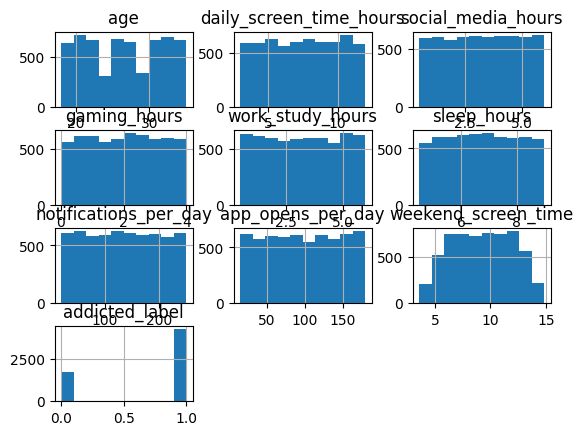

```python
df_train.hist()
```

General summary of our numerical features above.

```python
categorical_cols = df.select_dtypes(include=["object"]).columns
print(categorical_cols)
for col in categorical_cols:
    print(f"\n{col} Distribution:")
    print(df[col].value_counts())
```

```
Index(['transaction_id', 'user_id', 'gender', 'stress_level',
       'academic_work_impact', 'addiction_level'],
      dtype='object')

transaction_id Distribution:
transaction_id
TXN07500    1
TXN00001    1
TXN00002    1
TXN00003    1
TXN00004    1
           ..
TXN00017    1
TXN00016    1
TXN00015    1
TXN00014    1
TXN00013    1
Name: count, Length: 7500, dtype: int64

user_id Distribution:
user_id
U07500    1
U00001    1
U00002    1
U00003    1
U00004    1
         ..
U00017    1
U00016    1
U00015    1
U00014    1
U00013    1
Name: count, Length: 7500, dtype: int64

gender Distribution:
gender
Male      2553
Other     2486
Female    2461
Name: count, dtype: int64

stress_level Distribution:
stress_level
High      2560
Low       2503
Medium    2437
Name: count, dtype: int64

academic_work_impact Distribution:
academic_work_impact
No     3753
Yes    3747
Name: count, dtype: int64

addiction_level Distribution:
addiction_level
Moderate    2874
Severe      2434
Mild        1373
Name: count, dtype: int64
```

General summary of our categorical features.

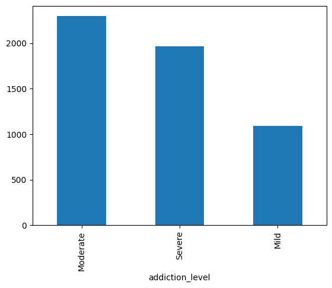

```python
df_train["addiction_level"].value_counts().plot(kind="bar")
```

As we see again, out target column in visualised way.

**2.3 Data Preprocessing**

```python
df_train = df_train.dropna(subset=["addiction_level"])
df_test = df_test.dropna(subset=["addiction_level"])
```

In here we dropped the missing parts in our target column.

```python
drop_cols = ["transaction_id", "user_id", "addicted_label"]
df_train = df_train.drop(columns=drop_cols)
df_test = df_test.drop(columns=drop_cols)
```

This step is not cruical but we wanted to delete unnecessary part of our data.

```python
target = "addiction_level"

x_train = df_train.drop(target, axis=1)
y_train = df_train[target]

x_test = df_test.drop(target, axis=1)
y_test = df_test[target]
```

Features and target is splitted to be sure everything is going well as planned.

**2.4 Feature Engineering of Our Data**

```python
current_x_train_df = df_train.drop(target, axis=1)
current_x_test_df = df_test.drop(target, axis=1)

categorical_features = current_x_train_df.select_dtypes(include=["object"]).columns
numerical_features = current_x_train_df.select_dtypes(include=["int64", "float64"]).columns
encoder = OneHotEncoder(handle_unknown="ignore")
scaler = StandardScaler()

preprocessor = ColumnTransformer(
    transformers=[
        ("cat", OneHotEncoder(handle_unknown="ignore"), categorical_features),
        ("num", StandardScaler(), numerical_features)
    ]
)

preprocessor.fit(current_x_train_df)

x_train = preprocessor.transform(current_x_train_df)
x_test = preprocessor.transform(current_x_test_df)

print("x_train size:", x_train.shape)
print("x_test size:", x_test.shape)
print("y_train size:", y_train.shape)
print("y_test size:", y_test.shape)
```

```
x_train size: (5358, 17)
x_test size: (1323, 17)
y_train size: (5358,)
y_test size: (1323,)
```

**2.5 Model Training**

For our problem, we want to try two different model training methods, also we want to test ensemble model. Then we want to see which one most suitable for our model. Firstly, we started to imply SVM.

```python
svm_model = SVC()
svm_model.fit(x_train, y_train)

y_pred = svm_model.predict(x_test)

print(" Accuracy : ", accuracy_score(y_test, y_pred))

print("\n Classification Report :")
print(classification_report(y_test, y_pred))

print("\n Confusion Matrix :")
print(confusion_matrix(y_test, y_pred))
```

```
 Accuracy :  0.5699168556311414

 Classification Report :
              precision    recall  f1-score   support

        Mild       0.77      0.78      0.78       279
    Moderate       0.51      0.58      0.55       578
      Severe       0.52      0.43      0.47       466

    accuracy                           0.57      1323
   macro avg       0.60      0.60      0.60      1323
weighted avg       0.57      0.57      0.57      1323


 Confusion Matrix :
[[217  60   2]
 [ 57 338 183]
 [  7 260 199]]
```

The baseline SVM model has an accuracy of about 57%. This shows that although there is some pattern recognition in the data that is being handled by the baseline SVM model, its score is hundred percent very low and needs to be improved.

The baseline SVM model is performing well in predicting the “Mild” class but is having difficulty in differentiating between “Moderate” and “Severe” classes. The confusion matrix is showing that there is a lot of confusion occurring in differentiating between “Moderate” and “Severe” classes. This is because there is not effective recognition of the difference between higher levels of addiction.

Now, we are gonna change our Model to see different outputs. Whether there are better results or not. We imply **Decision tree model** below.

```python
dt_model = DecisionTreeClassifier(random_state=42)
dt_model.fit(x_train, y_train)

y_pred = dt_model.predict(x_test)


print("Accuracy:", accuracy_score(y_test, y_pred))

print("\n  Report :")
print(classification_report(y_test, y_pred))

print("\n  Confusion Matrix :")
print(confusion_matrix(y_test, y_pred))
```

```
Accuracy: 0.5328798185941043

  Report :
              precision    recall  f1-score   support

        Mild       0.81      0.80      0.80       279
    Moderate       0.46      0.43      0.44       578
      Severe       0.46      0.51      0.48       466

    accuracy                           0.53      1323
   macro avg       0.58      0.58      0.58      1323
weighted avg       0.53      0.53      0.53      1323


  Confusion Matrix :
[[223  56   0]
 [ 53 246 279]
 [  0 230 236]]
```

As we can see above, decision tree model is not accurate as SVM. Our accuracy was %57 percent and now it is %53. Model mixes up moderate and severe classes but it is working well for Mild. Even better then SVM.

Why our model is weak? The Decision Tree model has performed relatively poorly due to the difficulty in identifying the complex and overlapping relationships between the “Moderate” and “Severe” classes. This is due to the highly flexible nature of the Decision Tree model, which makes it easily prone to overfitting the data and not performing well in generalizing the data, thus performing poorly in the separation of classes and the misclassification of the data between the classes. But we can use it while we are trying to ensemble the models.

Now, we are gonna try **random forest model** to move forward and then we will try to ensemble some models to see better results.

```python
rf_model = RandomForestClassifier(random_state=42)
rf_model.fit(x_train, y_train)

y_pred = rf_model.predict(x_test)

print(" Accuracy :", accuracy_score(y_test, y_pred))

print("\n Report :")
print(classification_report(y_test, y_pred))

print("\n Confusion Matrix :")
print(confusion_matrix(y_test, y_pred))
```

```
 Accuracy : 0.5789871504157218

 Report :
              precision    recall  f1-score   support

        Mild       0.78      0.86      0.82       279
    Moderate       0.52      0.51      0.51       578
      Severe       0.52      0.50      0.51       466

    accuracy                           0.58      1323
   macro avg       0.61      0.62      0.61      1323
weighted avg       0.57      0.58      0.58      1323


 Confusion Matrix :
[[239  40   0]
 [ 68 292 218]
 [  0 231 235]]
```

Random Forest was used because of its ability to cope with complex nonlinear relationships and prevent overfitting through ensemble learning. The algorithm is best for behavioral data sets that have many features that interact with each other.

```python
param_grid = {
    "n_estimators": [100, 200],
    "max_depth": [None, 10, 20],
    "min_samples_split": [2, 5],
    "max_features": ["sqrt", "log2"]
}

grid = GridSearchCV(
    RandomForestClassifier(random_state=42),
    param_grid,
    cv=3,
    scoring="f1_macro",
    n_jobs=-1
)

grid.fit(x_train, y_train)

print("Best Params:", grid.best_params_)
```

```
Best Params: {'max_depth': 20, 'max_features': 'sqrt', 'min_samples_split': 2, 'n_estimators': 100}
```

Hyperparameter tuning was used for the Random Forest model to optimize its performance. Hyperparameters like the number of trees, depth of trees, and feature selection method were tuned to optimize bias-variance trade-off and improve the model's ability to generalize.

Why we choose n = 100, 200 depth = 10,20 min samples = 2,5 because: The values used for the hyperparameters were chosen to ensure that different levels of complexity are tested without making the process too slow. Since n_estimators are commonly used values that yield stable results. The max_depth values were chosen to ensure that the complexity of the trees, both shallow and deeper, are used to prevent overfitting. The min_samples_split values are used to find a balance between a flexible model and a more general one. Lastly, the max_features options chosen, “sqrt” and “log2,” are commonly used to enhance the performance of the models by introducing randomness.

We could widen that but it would use too much cpu time.

```python
best_rf = grid.best_estimator_

y_pred = best_rf.predict(x_test)

print("Final Accuracy:", accuracy_score(y_test, y_pred))
print("\nFinal Report:")
print(classification_report(y_test, y_pred))
```

```
Final Accuracy: 0.5865457294028723

Final Report:
              precision    recall  f1-score   support

        Mild       0.79      0.88      0.83       279
    Moderate       0.53      0.50      0.51       578
      Severe       0.52      0.52      0.52       466

    accuracy                           0.59      1323
   macro avg       0.61      0.63      0.62      1323
weighted avg       0.58      0.59      0.58      1323
```

The model is still struggling to distinguish between these two classes Random Forest is the best model so far As expected, it outperformed the Decision Tree

Mild F1: 0.83

Here RandomForest performs very well here Better than SVM

Moderate F1: 0.51

Severe F1: 0.52

Because of the class imbalance in the dataset, accuracy alone is not sufficient to evaluate model performance. Therefore, the F1-scores are considered the primary evaluation metric, as it provides a balanced measure across all classes.

Finally we are gonna use different ensemble method; Which will be gradient boosting.

```python
gb_model = GradientBoostingClassifier(random_state=42)
gb_model.fit(x_train, y_train)

y_pred = gb_model.predict(x_test)

print("Accuracy:", accuracy_score(y_test, y_pred))
print(classification_report(y_test, y_pred))
```

```
Accuracy: 0.5918367346938775
              precision    recall  f1-score   support

        Mild       0.78      0.90      0.83       279
    Moderate       0.54      0.49      0.51       578
      Severe       0.53      0.53      0.53       466

    accuracy                           0.59      1323
   macro avg       0.61      0.64      0.63      1323
weighted avg       0.58      0.59      0.59      1323
```

In grradient boosting we saw the best results, if we test it more aggresively, I mean if we can train it in huge samples then we are gonna get better scores, cpu time will be more.

Among all the models, the best performance in the evaluation process has been obtained by the Gradient Boosting model. In comparison with other models, like SVM and Decision Tree, and the Random Forest model, the Gradient Boosting model has performed well in learning complex patterns in the data set. This is due to the reason that the boosting technique is used in the model, in which the focus is on learning from the previous errors.

The Gradient Boosting model has performed the best in comparison with other models due to the learning process of the model. In the Gradient Boosting model, the learning process is done sequentially. Unlike the Random Forest model, in the Gradient Boosting model, the trees are constructed one after the other, in which the focus is on learning the errors of the previous model. This helps the model in learning complex and overlapping classes, like the “Moderate” and “Severe” classes of addiction in the data set.

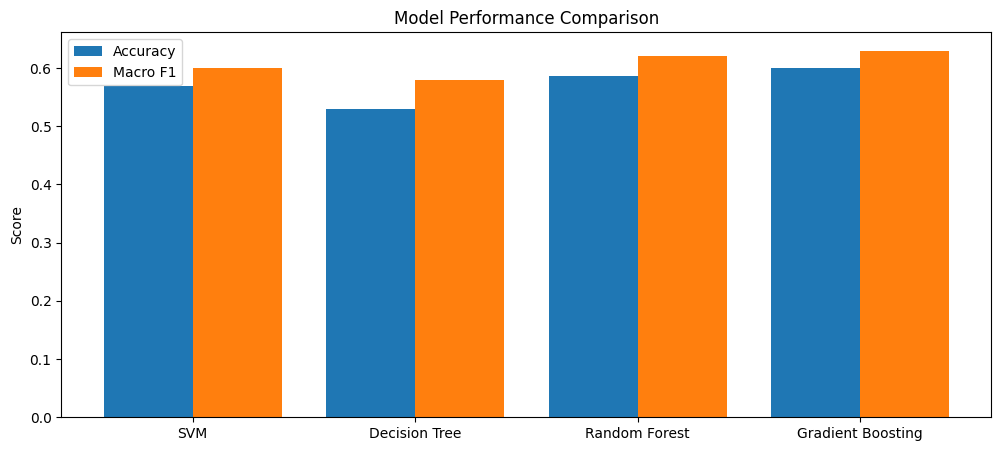

```python
models = ["SVM", "Decision Tree", "Random Forest", "Gradient Boosting"]
accuracy = [0.569, 0.53, 0.586, 0.60]
f1_scores = [0.60, 0.58, 0.62, 0.63]

x = range(len(models))

plt.figure(figsize=(12,5))

plt.bar(x, accuracy, width=0.4, label="Accuracy", align='center')
plt.bar([i + 0.4 for i in x], f1_scores, width=0.4, label="Macro F1")

plt.xticks([i + 0.2 for i in x], models)
plt.ylabel("Score")
plt.title("Model Performance Comparison")

plt.legend()
plt.show()
```

For better performance, further improvement is needed in terms of data representation as well as model optimization. Feature engineering might help in developing better features that can provide better discrimination between similar classes. Further improvement in hyperparameter tuning as well as cross-validation might also provide better results. Exploring better variants of boosting methods such as XGBoost or LightGBM might provide better results.

**3. Conclusion**

If we conclude, multiple models were created and tested. Gradient Boosting was seen to be the best model due to results. In addition to that, the macro F1 score was used to ensure that all classes were balanced in the evaluation.

*LIMITATIONS:*

The main limitation was that the classes “Moderate” and “Severe” were overlapping. We were struggling to find a way to improve scores. This made it hard to classify. In addition to that, the dataset lacked distinctive features. This reduced the accuracy of the model. In the end, the accuracy was moderate.

*IMPLICATION FOR BUSINESS:*

The model was classifying the users who were likely to have higher levels of addiction. This helped the company to be proactive in ensuring that the users were helped.

For better performance, the company can use detailed data and feature engineering techniques. Moreover, users can be grouped based on risk factors and take appropriate actions for them. The model can be further improved with new data.

4.References

Aftab, T. (2026). Digital Habits & Smartphone Addiction Dataset. [online] Kaggle.com. Available at: https://www.kaggle.com/datasets/guriya79/smart-phone/data?select=Smartphone_Usage_And_Addiction_Analysis_7500_Rows.csv [Accessed 26 Mar. 2026].

‌W3Schools (2025). W3Schools online web tutorials. [online] W3schools.com. Available at: https://www.w3schools.com/.

‌ Helped from AI to understanding the errors in my code.